# Análise de Saúde

Caroline de Oliveira e Matheus Monteiro Alves Melo

12/06/2025

## 1. Introdução

O presente relatório tem por objetivo principal descrever os dados relacionados às internações e mortes pelo uso de substâncias psicoativas nas cidades pertencentes ao Projeto Estado Presente, instituído em dezembro de 2017 no Espírito Santo. Segundo a Secretaria de Estado de Direitos Humanos, o projeto visa à redução dos índices de criminalidade, principalmente homicídios e roubos, em regiões de maior vulnerabilidade social. As cidades de Aracruz, Guarapari, Cariacica, Colatina, Linhares, São Mateus, Serra, Vila Velha e Vitória fazem parte do Estado Presente, que é aplicado em bairros específicos desses municípios.

Os dados utilizados foram obtidos no Painel Saúde, plataforma que reúne informações públicas sobre óbitos e internações, organizadas a partir do DataSUS (Ministério da Saúde), com base nas classificações internacionais de doenças (CID) relacionadas ao uso de álcool e outras drogas. As bases analisadas estão disponíveis no seguinte [site oficial](https://www.gov.br/mj/pt-br/assuntos/sua-protecao/politicas-sobre-drogas/obid/saude).

Os dados abrangem o período de 2000 a 2022, porém, neste relatório, as análises foram limitadas aos anos de 2013 a 2022. As bases analisadas são segmentadas em quatro categorias: Mortalidade por Álcool, Mortalidade por Outras Drogas, Internações por Álcool e Internações por Outras Drogas. Além disso, foi utilizada uma base populacional dos municípios do Espírito Santo, extraída do Instituto Brasileiro de Geografia e Estatística (IBGE) por meio do Sistema IBGE de Recuperação Automática (SIDRA) [Tabela populações](https://sidra.ibge.gov.br/tabela/6579).

As variáveis utilizadas neste relatório incluem o ano de ocorrência, o número de óbitos e internações por município e estado, além da população estimada para os respectivos locais. Para fins de clareza e legibilidade, os nomes técnicos dos códigos das variáveis não foram apresentados neste documento.

É importante ressaltar que o Projeto Estado Presente é aplicado a bairros específicos dentro dos municípios, e não ao município como um todo. Portanto, as análises apresentadas podem estar mascaradas, uma vez que agregam dados de áreas não contempladas pelo Projeto. Por exemplo, considerar todo o município de Vitória na análise pode diluir os efeitos observados nos bairros-alvo, como Nova Palestina. Abaixo, apresentamos a lista dos bairros atendidos pelo Projeto:

- Nova Palestina, Bairro da Penha e Piedade (Vitória);
- Barramares, Ulisses Guimarães, Boa Vista (I e II), São Torquato e Santa Rita (Vila Velha);
- Feu Rosa, Vila Nova de Colares, Jardim Carapina, Novo Horizonte, Planalto Serrano, Central Carapina e Bairro das Laranjeiras (Serra);
- Castelo Branco, Nova Rosa da Penha, Flexal II e Nova Esperança (Cariacica);
- Adalberto S. Nader e Kubitschek (Guarapari);
- Zumbi e Village da Luz (Cachoeiro de Itapemirim);
- Jacupemba (Aracruz);
- Ayrton Senna e Bela Vista (Colatina);
- Interlagos e Aviso (Linhares);
- Vila Nova e Bom Sucesso (São Mateus).

Este relatório está estruturado em nove seções. A seção 1 apresenta os dados utilizados e o contexto metodológico que fundamenta a análise. A seção 2 realiza uma análise com dados absolutos, permitindo compreender a dimensão dos eventos registrados; já na seção 3 são explorados indicadores que evidenciam a influência das ocorrências no estado. Em seguida, a seção 4 aborda as taxas de ocorrência, adotando as mesmas partições da seção anterior para aprofundar a perspectiva comparativa. A seção 5 foca nas taxas dos municípios participantes do Projeto Estado Presente. Na seção 6 são realizadas análises de tendência e autocorrelação, aplicando testes estatísticos para identificar padrões ao longo do tempo. Já a seção 7 avalia a qualidade dos dados disponíveis. A seção 8 aprofunda-se nas análises espaciais de autocorrelação, com destaque para a aplicação do índice de Moran. Por fim, a seção 9 apresenta as considerações finais e suas implicações para a formulação de políticas públicas.

### 1.1 Espírito Santo e municípios

Ao longo deste relatório, diversas comparações são feitas entre grupos de municípios e o estado. Para facilitar a compreensão, apresenta-se a seguir o mapa do Espírito Santo (Mapa 1).

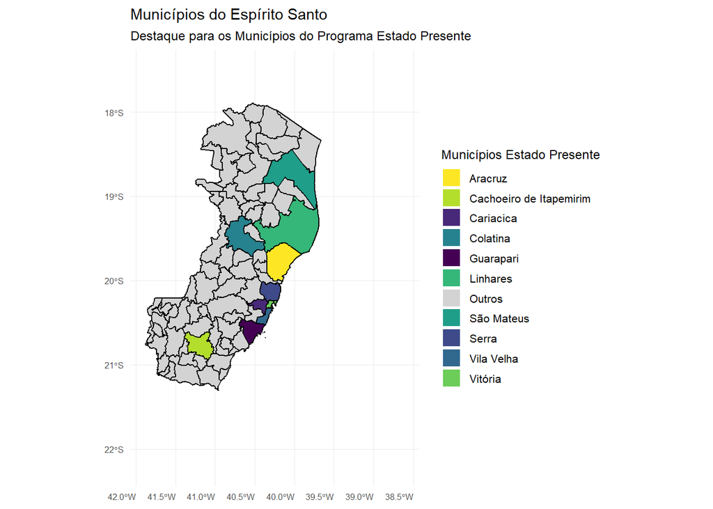

Mapa 1: ES e municípios do estado presente

O Espírito Santo é dividido em 78 municípios, com uma população ao longo dos anos representada por:

Tabela 1: População por Região e Ano

| Ano | Espírito Santo (ES) | Estado Presente (EP) | Demais Regiões | Proporção do EP no ES |
| --- | --- | --- | --- | --- |
| 2013 | 3839366 | 2462318 | 1377048 | 64.1% |
| 2014 | 3885049 | 2496594 | 1388455 | 64.3% |
| 2015 | 3929911 | 2530258 | 1399653 | 64.4% |
| 2016 | 3973697 | 2563052 | 1410645 | 64.5% |
| 2017 | 4016356 | 2594744 | 1421612 | 64.6% |
| 2018 | 3972388 | 2580773 | 1391615 | 65.0% |
| 2019 | 4018650 | 2616446 | 1402204 | 65.1% |
| 2020 | 4064052 | 2651458 | 1412594 | 65.2% |
| 2021 | 4108508 | 2685734 | 1422774 | 65.4% |
| 2022 | 3833712 | 2480513 | 1353199 | 64.7% |

Considerando os municípios mais populosos ao longo dos anos, conforme apresentado na Tabela 2, é importante destacar que muitos desses municípios também participam do Projeto Estado Presente. Esse fato pode justificar o maior número de ocorrências nessas localidades, como será observado ao longo do relatório.

Tabela 2: Top 5 Municípios Mais Populosos por Ano

| 2013 | 2014 | 2015 | 2016 | 2017 | 2018 | 2019 | 2020 | 2021 | 2022 |
| --- | --- | --- | --- | --- | --- | --- | --- | --- | --- |
| Vila Velha | Vila Velha | Serra | Serra | Serra | Vila Velha | Serra | Vila Velha | Vila Velha | Serra |
| Vitória | Serra | Vila Velha | Vila Velha | Vila Velha | Serra | Vila Velha | Cariacica | Serra | Vila Velha |
| Cariacica | Vitória | Cariacica | Vitória | Vitória | Vitória | Cariacica | Vitória | Vitória | Vitória |
| Serra | Cariacica | Vitória | Cariacica | Cachoeiro de Itapemirim | Cariacica | Vitória | Serra | Cariacica | Linhares |
| Cachoeiro de Itapemirim | Cachoeiro de Itapemirim | Cachoeiro de Itapemirim | Cachoeiro de Itapemirim | Cariacica | Cachoeiro de Itapemirim | Cachoeiro de Itapemirim | Cachoeiro de Itapemirim | Cachoeiro de Itapemirim | Cariacica |

## 2. Análise com valores absolutos

### 2.1 Internações

Os Gráficos 1 e 2 foram elaborados com base no total de internações registradas em cada local e ano. Observa-se que a série referente aos municípios do Estado Presente apresenta comportamento similar à série do Espírito Santo em ambos os gráficos, o que pode indicar que a maior parte das ocorrências no estado concentra-se nos municípios contemplados pelo projeto. Destaca-se também um declínio acentuado no número de casos no estado entre 2014 e 2015, com os menores valores registrados em 2016 (263 internações por uso de drogas, Gráfico 2) e em 2020 (821 internações por consumo de álcool, Gráfico 1).

No que tange às internações causadas pelo consumo de álcool, o Gráfico 1 mostra que, nos municípios do Estado Presente, houve 1.814 internações em 2013 e 362 em 2022, sendo este último o ano com o menor número de ocorrências. Já o Gráfico 2, que apresenta as internações por outras drogas, evidencia um comportamento com maiores oscilações, tendo ocorrido uma redução drástica no número de internações até 2016, seguida de um aumento entre 2016 e 2018. Quanto às internações nos municípios que não fazem parte do Projeto, observa-se um comportamento oposto ao dos demais: ao longo desses dez anos, o número de internações aumentou nesse grupo (com exceção de 2022), enquanto reduziu nos municípios participantes.

## Gráficos de Internações

[interactive chart not shown]

### 2.2 Óbitos

Assim como nos Gráficos 1 e 2, os Gráficos de óbitos 3 e 4 também demonstram similaridade entre as ocorrências registradas no estado como um todo e nos municípios contemplados pelo Projeto Estado Presente. É possível observar um crescimento mais acentuado no número de óbitos por uso de outras drogas no estado e nos municípios do Estado Presente em 2021 (32 mortes no estado e 25 no Estado Presente), enquanto nos demais anos esse número não ultrapassa 19.

## Gráficos de Óbitos

[interactive chart not shown]

## 3. Análise de indicadores

Indicadores são resumos de grandes quantidades de informações, utilizados para sintetizar e facilitar a descrição e interpretação dos dados. Eles são fundamentais para comparar tendências entre diferentes grupos, analisar o comportamento dos dados ao longo do tempo e avaliar o grau de impacto de uma informação sobre outra.

Neste relatório, foram criados quatro indicadores, descritos a seguir:

- Número de internações decorrentes do consumo de álcool nos municípios do Projeto Estado Presente a cada 100 internações decorrentes do consumo de álcool no estado;
- Número de internações decorrentes do uso de outras drogas nos municípios do Projeto Estado Presente a cada 100 internações decorrentes do uso de outras drogas no estado;
- Número de óbitos decorrentes do consumo de álcool nos municípios do Projeto Estado Presente a cada 100 óbitos decorrentes do consumo de álcool no estado;
- Número de óbitos decorrentes do uso de outras drogas nos municípios do Projeto Estado Presente a cada 100 óbitos decorrentes do uso de outras drogas no estado.

### 3.1 Indicadores de internações

Os indicadores apresentados nesta seção foram construídos a partir da razão entre o número de ocorrências anuais nos municípios participantes do Projeto Estado Presente e o número total de ocorrências, no mesmo ano, em todo o estado. Esses indicadores expressam a influência que as internações e mortes nos municípios contemplados pelo projeto exercem sobre os totais estaduais.

Indicador 1:

$$I_1 = \frac{\text{Nº de Internações Decorrentes do Consumo de Álcool nos
Municípios do Estado Presente}}{\text{Nº de Internações Decorrentes do
Consumo de Álcool no Espírito Santo}} \cdot 100
\tag{1}$$
Indicador 2:

$$I_2 = \frac{\text{Nº de Internações Decorrentes do Uso de Outras Drogas
nos Municípios do Estado Presente}}{\text{Nº de Internações Decorrentes
do Uso de Outras Drogas no Espírito Santo}} \cdot 100
\tag{2}$$
A partir do Gráfico 5, é possível perceber que em 2013, as internações causadas pelo uso de outras drogas representavam 99,64% das internações do estado (a cada 100 mortes no Espírito Santo, 99 delas foram em municípios contemplados pelo Projeto Estado Presente). E ao longo do tempo essa representação diminuiu, com seu menor percentual em 2021, quando as internações por drogas representam 61% das internações do estado. Em 2022 sofrem um leve aumento novamente (66,02%)

Assim como a internação por outras drogas, a internação por Álcool segue um comportamento similar. Começando em 2013 representando 89,40% das internações desta categoria no estado e finalizando em 2022 com 37,71%, tendo uma redução maior que a do indicador para outras drogas.

Interessante notar que para ambos os indicadores, a redução entre 2017 - 2022 (35,25% e 25,36% respectivamente) é superior a redução entre 2013 e 2017 (16,44% e 8,26%, respectivamente), além da COVID, outro evento presente nesse período foi o Projeto Estado Presente.

[interactive chart not shown]

### 3.2 Indicadores de mortalidade

Indicador 3:

$$I_3 = \frac{\text{Nº de Óbitos Decorrentes do Consumo de Álcool nos
Municípios do Estado Presente}}{\text{Nº de Óbitos Decorrentes do
Consumo de Álcool no Espírito Santo}} \cdot 100
\tag{3}$$
Indicador 4:

$$I_4 = \frac{\text{Nº de Óbitos Decorrentes do Uso de Outras Drogas nos
Municípios do Estado Presente}}{\text{Nº de Óbitos Decorrentes do Uso de
Outras Drogas no Espírito Santo}} \cdot 100
\tag{4}$$

Diferentemente dos indicadores relativos às internações, os indicadores associados aos óbitos apresentam comportamentos distintos. De acordo com o Gráfico 6, o Indicador 3 — que se refere às mortes por consumo de álcool — não sofreu grandes variações ao longo dos anos, apresentando uma redução de 3,04% no período analisado (2013 a 2022).

Já o Indicador 4, que contabiliza os óbitos relacionados ao uso de outras drogas, revela uma trajetória mais irregular. Em 2013, todos os óbitos registrados no estado relacionados a drogas (100%) ocorreram nos municípios participantes do Projeto Estado Presente. No entanto, esse percentual caiu drasticamente para 40% em 2017. A partir de 2018, observou-se uma retomada no crescimento desse índice, que atingiu 94,74% em 2019.

[interactive chart not shown]

## 4. Taxa de ocorrências pelas populações referentes

Para os gráficos apresentados a seguir, foi utilizada uma medida padronizada de comparação: a taxa de ocorrências por 100.000 habitantes. Essa abordagem permite comparar locais com diferentes tamanhos populacionais de forma proporcional, facilitando a identificação de padrões e tendências.

A taxa foi calculada conforme a fórmula abaixo:

$$Taxa = \frac{\text{Nº de Ocorrências no Local de
Interesse}}{\text{População do Respectivo Local}} \cdot 100000,
\tag{5}$$

Ou seja, cada valor representado nos gráficos corresponde ao número de ocorrências registradas por 100.000 habitantes naquele local e ano.

### 4.1 Internações

A análise dos Gráficos 7 e 8 revela uma tendência de queda semelhante nas séries do Espírito Santo e dos municípios participantes do Projeto Estado Presente ao longo dos anos — padrão já observado anteriormente nos Gráficos 1 e 2.

No Gráfico 7, observa-se um comportamento inverso nos municípios que não participam do projeto, em comparação às demais localidades. Enquanto as taxas de internações por consumo de álcool diminuem nos municípios do Estado Presente, nota-se um aumento gradual nessas regiões não contempladas. Essa inversão de tendência ocorre a partir de 2018, ano de implementação do projeto.

Em 2022, a taxa de internações por consumo de álcool foi de 44,19 a cada 100.000 habitantes nos municípios não participantes, enquanto nos municípios do Estado Presente a taxa foi de 14,59 por 100.000 habitantes. Outro ponto relevante é a queda acentuada entre 2014 e 2015: nos municípios do projeto, a taxa caiu de 68,2 para 29,25, redução superior à observada para o estado como um todo (de 49,7 para 24,6 internações por 100.000 habitantes).

Já o Gráfico 8, que trata das internações por uso de outras drogas, apresenta comportamento semelhante: as taxas caem tanto no estado quanto nos municípios do Estado Presente, enquanto aumentam nas regiões não contempladas. No entanto, diferentemente do observado para o consumo de álcool, os valores das taxas se aproximam nos anos de 2020, 2021 e 2022 — período coincidente com a pandemia de COVID-19 no Brasil, o que pode ter impactado os padrões de internação.

## Gráficos da Taxa de Internações

[interactive chart not shown]

### 4.2 Óbitos

Diferentemente dos Gráficos 7 e 8, o Gráfico 9 não apresentam variações acentuadas nas taxas ao longo do período analisado.

No Gráfico 9, observa-se que os três grupos de municípios — o Estado como um todo, os municípios participantes do Projeto Estado Presente e os demais municípios — exibem comportamentos semelhantes ao longo dos anos. No entanto, os municípios do Estado Presente mantêm, de forma consistente, as maiores taxas de óbitos por consumo de álcool, enquanto os municípios não contemplados apresentam as menores taxas.

Já no Gráfico 10, que trata das taxas de óbitos relacionados ao uso de outras drogas, os valores são significativamente mais baixos em comparação aos demais gráficos. Esse fato pode indicar uma menor quantidade de ocorrências registradas ou, alternativamente, uma possível subnotificação ou ausência de dados na base analisada.

## Gráficos da Taxa de Óbitos

[interactive chart not shown]

## 5. Taxa de ocorrências nos municípios do projeto

De forma similar à taxa de ocorrências apresentada anteriormente, nesta seção será utilizada a taxa por município, calculada da seguinte forma:

$$Taxa = \frac{\text{Nº de Ocorrências no Município de
Interesse}}{\text{População dos Referentes Município}} \cdot 100000,
\tag{6}$$
Assim, cada valor apresentado no gráfico representa a influência relativa de cada município nas ocorrências registradas no âmbito do Projeto Estado Presente — isto é, o número de ocorrências no município, por 100.000 habitantes, considerando apenas os municípios participantes do projeto naquele ano.

### 5.1 Internações

No Gráfico 11, observa-se uma taxa elevada nos anos de 2013 e 2014 no município de Cachoeiro de Itapemirim — não apenas em comparação com os demais municípios, mas também em relação aos próprios anos subsequentes do município. Esse comportamento atípico sugere a necessidade de uma investigação mais aprofundada para entender as causas de tais valores. Outro município que apresenta taxas consistentemente mais altas é Vitória, que mantém índices superiores aos dos demais municípios participantes do estudo.

No Gráfico 12, é possível verificar que Cachoeiro de Itapemirim também registra taxas elevadas de internações por uso de outras drogas nos anos de 2013 e 2014. Além disso, Vitória continua apresentando os maiores valores, mas observa-se também que Cariacica passa a exibir taxas relativamente mais altas entre 2018 e 2021 — período que coincide com a vigência do Projeto Estado Presente.

## Taxa de Internação nos Municípios

[interactive chart not shown]

### 5.2 Óbitos

Sobre as taxas de óbitos por município (Gráficos 13 e 14), não é possível identificar um padrão consistente. Para os óbitos decorrentes do consumo de álcool, destaca-se São Mateus, que apresentou as maiores taxas, especialmente em 2017, com 26,47 óbitos a cada 100.000 habitantes. Por outro lado, Guarapari registrou as menores taxas nesse indicador, chegando a 2,37 óbitos por 100.000 habitantes em 2020, o menor valor entre os municípios do projeto. Vitória também merece destaque, tendo apresentado uma taxa elevada em 2014 (19,31), seguida de uma tendência de queda até 2019, ano em que registrou sua menor taxa, com 9,39 óbitos por 100.000 habitantes.

Quanto à taxa de óbitos por uso de outras drogas, esse é o indicador com os menores valores entre os quatro gráficos de taxas municipais, o que pode indicar que essas substâncias são causa menos frequente de mortes nos municípios abrangidos pelo projeto. Ainda assim, chama atenção o comportamento de Aracruz, que manteve taxa zero durante os primeiros oito anos (2013-2020), mas apresentou a maior taxa do período entre os municípios do projeto em 2021, com 1,91 óbitos por 100.000 habitantes. Outro destaque é Guarapari, que exibiu taxas próximas de 1 ao longo do período, porém com quedas abruptas para zero em 2016 e 2018.

Cachoeiro de Itapemirim, que já se destacou nos Gráficos 11 e 12 por seu comportamento diferenciado em internações, apresentou, nos indicadores de óbitos relacionados ao álcool e outras drogas, valores mais alinhados com os demais municípios, com leves oscilações no Gráfico 13 e taxas inferiores a 0,5 óbito por 100.000 habitantes por uso de outras drogas. Em anos específicos — 2013, 2015, 2016, 2017 e 2019 — essas taxas foram nulas. Entretanto, é importante salientar que o município não possui dados disponíveis sobre óbitos por uso de outras drogas nos anos de 2021 e 2022, o que pode indicar defasagem ou ausência de atualização na base de dados utilizada.

## Taxa de Óbitos nos Municípios

[interactive chart not shown]

## 6. Análise de tendência

Além das análises descritivas realizadas ao longo do relatório, também foram investigadas as séries temporais — ou seja, o comportamento das internações e óbitos ao longo do tempo — causados pelo consumo de álcool e pelo uso de outras drogas nos municípios participantes do Projeto Estado Presente, no período de 2013 a 2022.

Para isso, utilizamos dois tipos de testes estatísticos importantes:

- **Teste de tendência (Mann-Kendall):** que serve para identificar se há uma tendência clara de aumento ou diminuição nos dados ao longo do tempo, como uma melhora ou piora contínua em internações e óbitos;
- **Teste de autocorrelação (Ljung-Box):** que verifica se os dados observados em um ano estão relacionados aos anos anteriores, ou seja, se existe alguma repetição ou padrão que se mantém ao longo do tempo.

Esses testes foram aplicados tanto para as taxas globais de internações e óbitos no conjunto dos municípios do Projeto Estado Presente (representados nos Gráficos 7 a 10), quanto para as taxas específicas de cada município individualmente (Gráficos 11 a 14).

Os resultados, organizados nas Tabelas 3, 4 e 5, nos ajudam a compreender se as variações observadas são simples flutuações aleatórias ou se indicam mudanças reais e consistentes no comportamento das internações e mortes relacionadas ao uso de álcool e outras drogas.

Para facilitar a interpretação dos testes, adotamos os seguintes critérios:

- Quando o teste de autocorrelação detecta um padrão (p < 0,05), isso indica que os números de um ano podem influenciar os anos seguintes, evidenciando um comportamento persistente;
- Quanto à tendência, classificamos como “Crescente” se os dados indicam aumento consistente ao longo do tempo, “Decrescente” para redução, “Neutra” quando não há tendência clara, e “Quase significativa” quando a evidência é próxima de ser estatisticamente confiável.

Com essa análise, podemos entender melhor se as ações do Projeto Estado Presente estão relacionadas a mudanças reais no número de internações e óbitos, e se essas mudanças tendem a continuar.

### 6.1 Testes para taxa no conjunto Estado Presente

Em relação às internações por álcool nos municípios contemplados pelo Projeto Estado Presente, não foram encontradas evidências estatísticas que indiquem uma tendência significativa de aumento ou redução nas taxas ajustadas pela população durante o período analisado (conforme ilustrado no Gráfico 7). Por outro lado, as internações decorrentes do uso de outras drogas apresentaram uma redução estatisticamente significativa nas taxas após o início do projeto ($p < 0{,}05$), como mostrado no Gráfico 8. Esses resultados sugerem que, no âmbito das internações, o Projeto Estado Presente exerceu maior impacto no enfrentamento das consequências associadas ao consumo de outras drogas em comparação ao álcool.

Quanto aos óbitos relacionados ao uso de substâncias psicoativas, os achados revelam distinções conforme o tipo de substância. No caso do álcool, as taxas de mortalidade não demonstraram tendência significativa de aumento ou diminuição após a implementação do Projeto (Gráfico 9). Já para os óbitos associados ao uso de outras drogas, foi observada uma tendência significativa de queda antes da implantação do projeto ($p < 0{,}05$), que se estabilizou em um comportamento mais neutro no período subsequente (Gráfico 10).

Tabela 3. Resultados dos Testes Ljung-Box e Mann-Kendall nas Taxas do Conjunto Estado Presente (2013–2022).

| Indicador (em taxa) | Periodo | P-Valor (Ljung-Box) | Autocorrelação | Mann Kendall S | MK Tau τ | MK P-Valor | Tendência |
| --- | --- | --- | --- | --- | --- | --- | --- |
| Internações por álcool | Antes(2013–2017) | 0.294 | Não | -8 | 16.667 | 0.086 | Quase sig. |
| Internações por álcool | Depois(2018–2022) | 0.278 | Não | -8 | 16.667 | 0.086 | Quase sig. |
| Internações por drogas | Antes(2013–2017) | 0.296 | Não | -8 | 16.667 | 0.086 | Quase sig. |
| Internações por drogas | Depois(2018–2022) | 0.575 | Não | -10 | 16.667 | 0.027 | Decrescente |
| Óbitos por álcool | Antes(2013–2017) | 0.972 | Não | -6 | 16.667 | 0.221 | Neutra |
| Óbitos por álcool | Depois(2018–2022) | 0.239 | Não | 0 | 16.667 | 1.000 | Neutra |
| Óbitos por drogas | Antes(2013–2017) | 0.403 | Não | -10 | 16.667 | 0.027 | Decrescente |
| Óbitos por drogas | Depois(2018–2022) | 0.142 | Não | -2 | 16.667 | 0.806 | Neutra |

### 6.2 Testes para taxas por município do Projeto

#### 6.2.1 Internações

A análise desagregada por município referente às internações (Tabela 4) revelou que apenas Vitória apresentou uma tendência significativa de redução nas taxas de internação por drogas após a implementação do Projeto Estado Presente. Nos demais municípios participantes, não foram identificadas tendências estatísticas claras de crescimento ou diminuição nas internações relacionadas ao consumo de álcool ou ao uso de outras drogas. Um caso particular é o de Cachoeiro de Itapemirim, município integrante do Estado Presente, que apresentou uma expressiva tendência de redução nas internações por álcool e outras drogas no período anterior à implementação do projeto, sem alterações relevantes no período posterior. Esses resultados podem ser visualizados nos Gráficos 11 e 12, que ilustram as taxas de internação por álcool e outras drogas nos municípios participantes ao longo do tempo.

**Tabela 4.** Resultados dos Testes Ljung-Box e Mann-Kendall para Internações por Município (2013–2022).

| Município | Indicador | Período | p_Valor(Ljung-Box) | Autocorrelação | S (Mann-Kendall) | Tau (τ) | p_Valor(Mann-Kendall) | Tendência |
| --- | --- | --- | --- | --- | --- | --- | --- | --- |
| Aracruz | Internações por drogas | Antes (2013–2017) | 0.33 | Não | 0 | 8 | 1 | Neutra |
| Aracruz | Internações por drogas | Depois (2018–2022) | 0.823 | Não | 3 | 5 | 0.371 | Neutra |
| Aracruz | Internações por álcool | Antes (2013–2017) | 0.515 | Não | 0 | 16.667 | 1 | Neutra |
| Aracruz | Internações por álcool | Depois (2018–2022) | 0.361 | Não | -2 | 16.667 | 0.806 | Neutra |
| Cachoeiro de Itapemirim | Internações por drogas | Antes (2013–2017) | 0.319 | Não | -10 | 16.667 | 0.027 | Decrescente |
| Cachoeiro de Itapemirim | Internações por drogas | Depois (2018–2022) | 0.588 | Não | -6 | 16.667 | 0.221 | Neutra |
| Cachoeiro de Itapemirim | Internações por álcool | Antes (2013–2017) | 0.312 | Não | -10 | 16.667 | 0.027 | Decrescente |
| Cachoeiro de Itapemirim | Internações por álcool | Depois (2018–2022) | 0.567 | Não | -4 | 16.667 | 0.462 | Neutra |
| Cariacica | Internações por drogas | Antes (2013–2017) | 0.378 | Não | -2 | 16.667 | 0.806 | Neutra |
| Cariacica | Internações por drogas | Depois (2018–2022) | 0.831 | Não | -6 | 16.667 | 0.221 | Neutra |

[output cut: 30 more lines]

#### 6.2.3 Óbitos

Na análise desagregada por município referente aos óbitos (Tabela 5 e Gráficos 13 e 14), apenas Guarapari apresentou autocorrelação significativa nos dados, indicando que as observações desse município podem não ser independentes ao longo do tempo. Quanto ao teste de tendência, Aracruz mostrou aumento significativo na mortalidade por consumo de álcool antes da implantação do Projeto Estado Presente, mantendo-se estável após o início do projeto. Cariacica e Serra apresentaram redução significativa nos óbitos por outras drogas no período anterior ao projeto, enquanto Vila Velha apresentou essa redução no período posterior à implantação.

**Tabela 5.** Resultados dos Testes Ljung-Box e Mann-Kendall para Óbitos por Município (2013–2022).

| Município | Indicador | Período | p_Valor(Ljung-Box) | Autocorrelação | S (Mann-Kendall) | Tau (τ) | p_Valor(Mann-Kendall) | Tendência |
| --- | --- | --- | --- | --- | --- | --- | --- | --- |
| Aracruz | Óbitos por drogas | Antes (2013–2017) | NaN | NA | 0 | 0 | NaN | Neutra |
| Aracruz | Óbitos por drogas | Depois (2018–2022) | 0.823 | Não | 3 | 5 | 0.371 | Neutra |
| Aracruz | Óbitos por álcool | Antes (2013–2017) | 0.456 | Não | 10 | 16.667 | 0.027 | Crescente |
| Aracruz | Óbitos por álcool | Depois (2018–2022) | 0.509 | Não | 4 | 16.667 | 0.462 | Neutra |
| Cachoeiro de Itapemirim | Óbitos por drogas | Antes (2013–2017) | 0.636 | Não | -2 | 8 | 0.724 | Neutra |
| Cachoeiro de Itapemirim | Óbitos por drogas | Depois (2018–2022) | 0.153 | Não | -1 | 3.667 | 1 | Neutra |
| Cachoeiro de Itapemirim | Óbitos por álcool | Antes (2013–2017) | 0.986 | Não | -4 | 16.667 | 0.462 | Neutra |
| Cachoeiro de Itapemirim | Óbitos por álcool | Depois (2018–2022) | 0.161 | Não | -2 | 16.667 | 0.806 | Neutra |
| Cariacica | Óbitos por drogas | Antes (2013–2017) | 0.251 | Não | -10 | 16.667 | 0.027 | Decrescente |
| Cariacica | Óbitos por drogas | Depois (2018–2022) | 0.463 | Não | 2 | 8.667 | 0.734 | Neutra |

[output cut: 30 more lines]

## 7. Qualidade dos Dados

Para a confecção dos mapas desta seção, foram incluídos todos os municípios do estado. Aqueles que não apresentaram dados aparecem sem tonalização (NA) na base, o que pode gerar incertezas na interpretação espacial dos fenômenos analisados.

### 7.1 Outras Drogas

A análise dos dados de internações e óbitos relacionados ao uso de outras drogas revelou uma distribuição espacial bastante desigual entre os municípios do Espírito Santo nos anos de 2017 a 2022. Observou-se uma ausência significativa de registros em diversos municípios, sobretudo no ano de 2022. Esse padrão pode refletir uma redução real nos eventos ou estar associado à subnotificação e à interrupção dos fluxos de informação durante o período da pandemia de COVID-19.

O contexto pandêmico provavelmente afetou tanto o acesso aos serviços de saúde quanto os mecanismos de registro e codificação dos atendimentos hospitalares e das causas de óbito. Consequentemente, vários municípios — especialmente os de menor porte — apresentaram lacunas nos registros, comprometendo a análise temporal e resultando em séries históricas truncadas ou descontinuadas. Essa limitação informacional também impacta a robustez de análises de autocorrelação espacial, como o Índice de Moran Local (discutido na Seção 8), já que a ausência de dados pode induzir a interpretações equivocadas de concentração ou dispersão dos eventos.

Portanto, os resultados referentes às ocorrências associadas a outras drogas devem ser interpretados com cautela. As limitações estruturais dos sistemas de informação em determinados territórios, agravadas pelo contexto da pandemia, impõem restrições à interpretação confiável dos padrões espaciais e temporais observados. Estudos futuros poderão se beneficiar do uso de técnicas de imputação de dados ou modelagens que incorporem a incerteza, permitindo um tratamento mais robusto das áreas com baixa cobertura informacional.

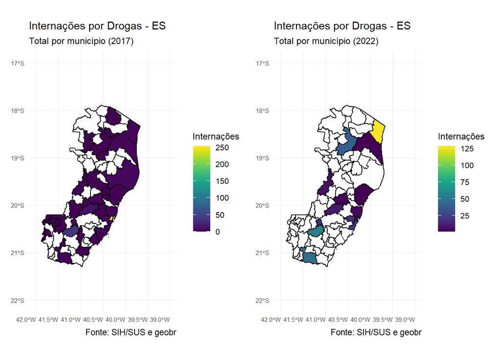

Mapa 2: Internação por outras drogas em 2017 e 2022

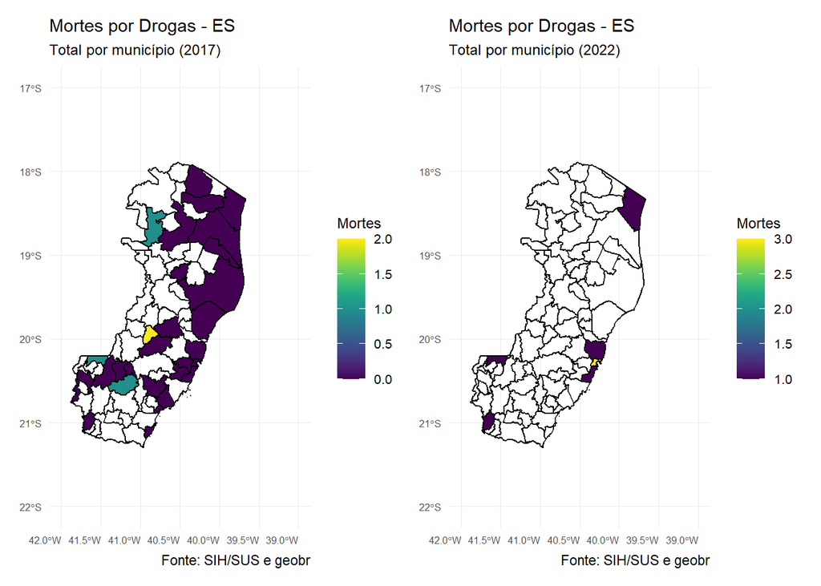

Mapa 3: Óbitos por outras drogas em 2017 e 2022

### 7.2 Álcool

Em contraste com os dados referentes ao uso de outras drogas, os mapas 4 e 5, que representam as internações e óbitos relacionados ao consumo de álcool, apresentaram maior consistência e continuidade nos registros ao longo do período analisado. Essa estabilidade pode indicar que os sistemas de registro vinculados a causas associadas ao álcool foram menos impactados pelas interrupções provocadas pela pandemia de COVID-19, ou ainda que a aparente instabilidade nos dados de outras drogas decorre, em parte, do menor número absoluto de casos registrados para essas substâncias. Dessa forma, é possível realizar inferências mais confiáveis tanto sobre padrões espaciais quanto sobre tendências temporais relacionadas ao álcool.

A abrangência e uniformidade dos registros nos municípios permitem uma avaliação territorial mais robusta dos efeitos do Projeto Estado Presente. Os dados de 2017 — ano anterior à implementação do projeto — e de 2022 — período posterior ao auge da pandemia — oferecem uma base adequada para analisar variações na magnitude de internações e óbitos relacionados ao álcool, possibilitando ainda a aplicação de métodos sensíveis a variações locais, como indicadores de autocorrelação espacial e testes de tendência temporal.

Esse contraste entre os dados de álcool e outras drogas reforça a importância de uma avaliação criteriosa da qualidade e cobertura das bases de dados antes da realização de inferências sobre o impacto de políticas públicas. Enquanto os dados relativos ao álcool se mostraram mais confiáveis para análises territoriais, os referentes às outras drogas demandam abordagens metodológicas mais cautelosas para evitar a atribuição indevida de padrões espúrios a políticas ou a eventos contextuais, como a pandemia.

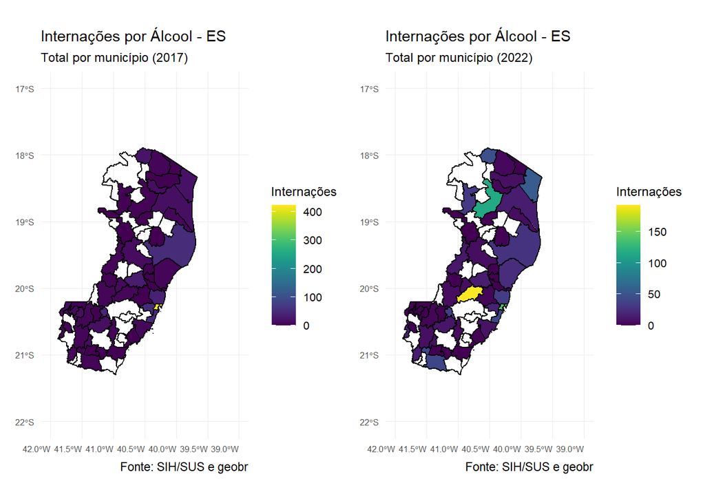

Mapa 4: Internação por álcool em 2017 e 2022

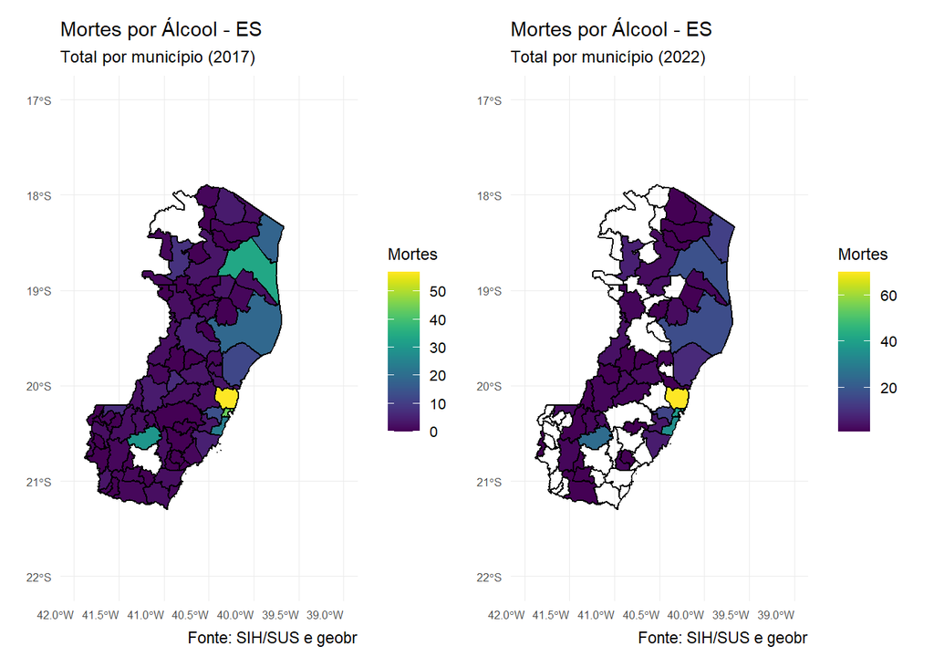

Mapa 5: Óbitos por álcool em 2017 e 2022

## 8. Análise de Correlação Espacial

Para investigar padrões espaciais relacionados às internações e óbitos por álcool e outras drogas, foram realizadas análises de autocorrelação espacial utilizando o Índice de Moran Local (LISA). Este índice identifica agrupamentos geográficos (clusters), indicando regiões com valores semelhantes ou discrepantes em relação aos municípios vizinhos.

As tabelas 6 a 9 apresentam os resultados detalhados do LISA para cada estrato analisado, incluindo o índice $I$, o p-valor e a classificação do cluster para cada município do Espírito Santo.

Na análise das **internações por álcool** (Tabela 6), Vitória apresentou autocorrelação espacial significativa, sendo classificada como município “baixo-alto”. Isso indica uma baixa taxa local de internações cercada por municípios com taxas elevadas, possivelmente refletindo a infraestrutura urbana da capital. Nos demais municípios, os índices não apontaram autocorrelações significativas.

Já para as **internações por outras drogas** (Tabela 7), não foram detectados clusters significativos, o que sugere uma maior variabilidade territorial sem agrupamentos espaciais claros.

Quanto aos **óbitos por álcool** (Tabela 8) e **óbitos por outras drogas** (Tabela 9), também não foram encontradas autocorrelações espaciais estatisticamente significativas nos municípios analisados.

Esses resultados indicam que, em geral, não há fortes padrões locais de dependência espacial para internações e óbitos relacionados ao uso de substâncias psicoativas, exceto pelo caso específico de Vitória nas internações por álcool. A ausência de clusters pode estar associada à complexidade dos determinantes sociais, econômicos e de saúde que influenciam esses desfechos em escala municipal.

Tabela 6: Índice de Moran Local para Internações por Álcool (2022)

| Município | Índice Moran (I) | p-valor | Cluster |
| --- | --- | --- | --- |
| Aracruz | 0.190 | 0.696 | Não significativo |
| Cachoeiro de Ita. | 0.000 | NA | Não significativo |
| Cariacica | 0.112 | 0.153 | Não significativo |
| Colatina | 0.150 | 0.707 | Não significativo |
| Guarapari | -0.628 | 0.355 | Não significativo |
| Linhares | 0.165 | 0.321 | Não significativo |
| São Mateus | 0.155 | 0.706 | Não significativo |
| Serra | -0.372 | 0.138 | Não significativo |
| Vila Velha | 0.517 | 0.212 | Não significativo |
| Vitória | -0.612 | 0.041 | Baixo-Alto |

Tabela 7: Índice de Moran Local para Internações por Outras Drogas (2022)

| Município | Índice Moran (I) | p-valor | Cluster |
| --- | --- | --- | --- |
| Aracruz | 0.223 | 0.653 | Não significativo |
| Cachoeiro de Ita. | 0.000 | NA | Não significativo |
| Cariacica | -0.453 | 0.385 | Não significativo |
| Colatina | -0.033 | 0.707 | Não significativo |
| Guarapari | -0.296 | 0.648 | Não significativo |
| Linhares | 0.135 | 0.468 | Não significativo |
| São Mateus | 0.215 | 0.655 | Não significativo |
| Serra | -0.537 | 0.114 | Não significativo |
| Vila Velha | 0.308 | 0.221 | Não significativo |
| Vitória | -0.524 | 0.082 | Não significativo |

Tabela 8: Índice de Moran Local para Óbitos por Álcool (2022)

| Município | Índice Moran (I) | p-valor | Cluster |
| --- | --- | --- | --- |
| Aracruz | 0.685 | 0.445 | Não significativo |
| Cachoeiro de Ita. | 0.000 | NA | Não significativo |
| Cariacica | -0.335 | 0.173 | Não significativo |
| Colatina | 0.030 | 0.548 | Não significativo |
| Guarapari | -1.994 | 0.107 | Não significativo |
| Linhares | -0.110 | 0.838 | Não significativo |
| São Mateus | -1.046 | 0.613 | Não significativo |
| Serra | -0.333 | 0.681 | Não significativo |
| Vila Velha | -1.086 | 0.297 | Não significativo |
| Vitória | -0.218 | 0.194 | Não significativo |

Tabela 9: Índice de Moran Local para Óbitos por Outras Drogas (2022)

| Município | Índice Moran (I) | p-valor | Cluster |
| --- | --- | --- | --- |
| Aracruz | 0.834 | 0.339 | Não significativo |
| Cachoeiro de Ita. | 0.000 | NA | Não significativo |
| Cariacica | -0.356 | 0.396 | Não significativo |
| Colatina | -1.095 | 0.463 | Não significativo |
| Guarapari | -0.650 | 0.204 | Não significativo |
| Linhares | -0.411 | 0.436 | Não significativo |
| São Mateus | -0.971 | 0.463 | Não significativo |
| Serra | -0.772 | 0.318 | Não significativo |
| Vila Velha | -0.920 | 0.270 | Não significativo |
| Vitória | -0.473 | 0.355 | Não significativo |

## 9. Conclusões

A comparação entre os anos de 2017 (pré-implementação do Projeto) e 2022 (pós-pandemia) evidenciou crescimento das internações em municípios como Linhares e São Mateus, ao passo que Vitória e Vila Velha apresentaram redução, sugerindo impactos territoriais diferenciados da política pública. Contudo, é importante ressaltar uma limitação relevante: as análises foram realizadas em nível municipal, embora o Projeto Estado Presente atue em bairros específicos. Essa discrepância pode ter mascarado variações significativas dentro dos municípios, especialmente em áreas de maior vulnerabilidade social.

Adicionalmente, os efeitos da pandemia de COVID-19 possivelmente influenciaram os registros de internações e óbitos, sobretudo nos anos de 2020 e 2021, impactando os sistemas de saúde e os fluxos de informação. Recomenda-se que estudos futuros adotem escalas mais detalhadas — como bairros ou setores censitários — e incorporem variáveis socioeconômicas e de acesso a serviços de saúde, a fim de orientar a formulação de políticas públicas mais direcionadas, eficazes e sensíveis às desigualdades territoriais.